# ggfortify: Unified Interface to Visualize Statistical Results of Popular R Packages

The *ggfortify* package provides a unified interface that enables users to use one line of code to visualize statistical results of many R packages using *ggplot2* idioms. With the help of *ggfortify*, statisticians, data scientists, and researchers can avoid the sometimes repetitive work of using the *ggplot2* syntax to achieve what they need.

Yuan Tang (Uptake Technologies, Inc.) , Masaaki Horikoshi (Accenture Japan Ltd.) , Wenxuan Li (Department of Agricultural Economics, Purdue University)  
2016-09-10

## 1 Background

R users have many plotting options to choose from, such as base graphics, grid graphics, and [*lattice*](https://CRAN.R-project.org/package=lattice) graphics (Sarkar 2008). Each has their own unique customization and extensibility options. In recent years, [*ggplot2*](https://CRAN.R-project.org/package=ggplot2) has emerged as a popular choice for creating visualizations (Wickham 2009) and provides a strong programming model based on a “grammar of graphics” which enables methodical production of virtually any kind of statistical chart. The *ggplot2* package makes it possible to describe a wide range of graphics with succinct syntax and independent components and is based on an object-oriented model that also makes it modular and extensible. It has become a widely used framework for producing statistical graphics in R.  
The distinct syntax of *ggplot2* makes it a definite paradigm shift from base and *lattice* graphics and presents a somewhat steep learning curve for those used to existing R charting idioms. Often times users only want to quickly visualize some statistical results from key R packages, especially those focusing on clustering and time series analysis. Many of these packages provide default base `plot()` visualizations for the data and models they generate. These components require transformation before using them in *ggplot2* and each of those transformation steps must be replicated by others when they wish to produce similar charts in their analyses. Creating a central repository for common/popular transformations and default plotting idioms would reduce the amount of effort needed by all to create compelling, consistent and informative charts. To achieve this, we provide a unified *ggplot2* plotting interface to many statistics and machine-learning packages and functions in order to help these users achieve reproducibility goals with minimal effort.  
The [*ggfortify*](https://CRAN.R-project.org/package=ggfortify) (Horikoshi and Y. Tang 2015) package has a very easy-to-use and uniform programming interface that enables users to use one line of code to visualize statistical results of many popular R packages using *ggplot2* as a foundation. This helps statisticians, data scientists, and researchers avoid both repetitive work and the need to identify the correct *ggplot2* syntax to achieve what they need. With *ggfortify*, users are able to generate beautiful visualizations of their statistical results produced by popular packages with minimal effort.

## 2 Software architecture

There are many ways to extend the functionality of *ggplot2*. One straightforward way is through the use of S3 generic functions [^1]. Specifically, it is possible to provide custom functions for:

- `autoplot()`, which enables plotting a custom object with *ggplot2*, and
- `fortify()`, which enables converting a custom object to a tidy `"data.frame"`

The *ggforitfy* package uses this extensibility to provide default *ggplot2* visualizations and data transformations.  
To illustrate this, we consider the implementation for `fortify.prcomp()` and `autoplot.pca_common()` used as a basis of other PCA related implementations:

```r
fortify.prcomp <- function(model, data = NULL, ...) {

  if (is(model, "prcomp")) {
    d <- as.data.frame(model$x)
    values <- model$x %*% t(model$rotation)
  } else if (is(model, "princomp")) {
    d <- as.data.frame(model$scores)
    values <- model$scores %*% t(model$loadings[,])
  } else {
    stop(paste0("Unsupported class for fortify.pca_common: ", class(model)))
  }

  values <- ggfortify::unscale(values, center = model$center,
                               scale = model$scale)
  values <- cbind_wraps(data, values)
  d <- cbind_wraps(values, d)
  post_fortify(d)
}
```

This S3 function recognizes `"prcomp"` objects and will extract the necessary components from them such as the matrix whose columns contain the eigenvectors in `"rotation"` and rotated data in `"x"`, which can be drawn using `autoplot()` later on. The `if()` call is used here to handle different objects that are of essentially the same principal components family since they can be handled in the exactly same way once the necessary components are extracted from *ggfortify*.  
The following `autoplot.pca_common()` function first calls `fortify()` to perform the component extraction for different PCA-related objects, then performs some common data preparation for those objects, and finally calls `ggbiplot()` internally to handle the actual plotting.

```r
autoplot.pca_common <- function(object, data = NULL,
                                scale = 1.0, ...) {

  plot.data <- ggplot2::fortify(object, data = data)
  plot.data$rownames <- rownames(plot.data)

  if (is_derived_from(object, "prcomp")) {
    x.column <- "PC1"
    y.column <- "PC2"
    loadings.column <- "rotation"

    lam <- object$sdev[1L:2L]
    lam <- lam * sqrt(nrow(plot.data))

  } else if (is_derived_from(object, "princomp")) {
    ...
  } else {
    stop(paste0("Unsupported class for autoplot.pca_common: ", class(object)))
  }

  # common and additional preparation before plotting
  ...

  p <- ggbiplot(plot.data = plot.data,
                loadings.data = loadings.data, ...)
  return(p)
}
```

Once *ggfortify* is loaded, users have instant access to 38 pre-defined `autoplot()` functions and 36 pre-defined `fortify()` functions, enabling them to immediately `autoplot()` numerous types of objects or pass those objects directly to *ggplot2* for manual customization. Furthermore, *ggfortify* is highly extensible and customizable and provides utility functions that make it easy for users to define `autoplot()` and `fortify()` methods for their own custom objects.  
To present a streamlined API, *ggfortify* groups common implementations for various object-types, including:

- Time-series
- Principal components analysis (PCA), including clustering and multi-dimensional sacling (MDS)
- 1d/2d kernel density estimation (KDE)
- Survival analysis
- Cartography

A list of currently supported packages and classes can be found in Table 1. Additional packages that are in development are not shown here but more than 50 object types are supported by *ggfortify*. Feedback is being collected from users[^2] for possible bug fixes and future enhancements.

Table 1: Supported packages

| package | supported types | package | supported types |
| --- | --- | --- | --- |
| *base* | `"matrix"`, `"table"` | *sp* | `"SpatialPoints"`, `"SpatialPolygons"`, `"Line"`, `"Lines"`, `"Polygon"`, `"Polygons"`, `"SpatialLines"`, `"SpatialLinesDataFrame"`, `"SpatialPointsDataFrame"`, `"SpatialPolygonsDataFrame"` |
| *cluster* | `"clara"`, `"fanny"`, `"pam"` | *stats* | `"HoltWinters"`, `"lm"`, `"acf"`, `"ar"`, `"Arima"`, `"stepfun"`, `"stl"`, `"ts"`,`"cmdscale"`, `"decomposed.ts"`, `"density"`, `"factanal"`, `"glm"`, `"kmeans"`, `"princomp"`, `"spec"` |
| *changepoint* | `"cpt"` | *survival* | `"survfit"`, `"survvfit.cox"` |
| *dlm* | `"dlmFilter"`, `"dlmSmooth"` | *strucchange* | `"breakpoints"`, `"breakpointsfull"` |
| *fGarch* | `"fGARCH"` | *timeSeries* | `"timeSeries"` |
| *forecast* | `"bats"`, `"forecast"`, `"ets"`, `"nnetar"` | *tseries* | `"irts"` |
| *fracdiff* | `"fracdiff"` | *vars* | `"varprd"` |
| *glmnet* | `"cv.glmnet"`, `"glmnet"` | *xts* | `"xts"` |
| *KFAS* | `"KFS"`, `"signal"` | *zoo* | `"zooreg"` |
| *lfda* | `"lfda"`, `"klfda"`, `"self"` | *MASS* | `"isoMDS"`, `"sammon"` |
| *maps* | `"map"` |  |  |

## 3 Illustrations

As previously stated, *ggfortify* provides methods that enable *ggplot2* to work with objects in different classes from different R packages. The following subsections illustrate how to use *ggfortify* to plot results from several of these packages.

### 3.1 Principal components analysis

The *ggfortify* package defines both `fortify()` and `autoplot()` methods for the two core PCA functions in the *stats* package: `stats::prcomp()` and `stats::princomp()`. The values returned by either function can be passed directly to `ggplot2::autoplot()` as illustrated in the following code and in Figure 1. Note that users can also specify a column to be used for the `colour` aesthetic.

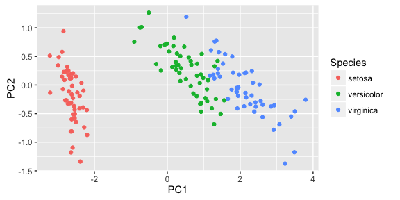

Figure 1: PCA with colors for each class.

```r
library(ggfortify)
df <- iris[c(1, 2, 3, 4)]
autoplot(prcomp(df), data = iris, colour = "Species")
```

If `label = TRUE` is specified, as shown in Figure 2, *ggfortify* will draw labels for each data point. Users can also specify the size of the labels via `label.size`. If `shape = FALSE` is specified, the shape of the data points will be removed, leaving only the labels on the plot.

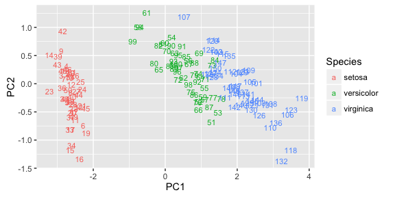

Figure 2: PCA with colors and labels for each class.

```r
autoplot(prcomp(df), data = iris, colour = "Species", shape = FALSE, label.size = 3)
```

The `autoplot` function returns the constructed *ggplot2* object so users can apply additional *ggplot2* code to further enhance the plot. For example:

```r
autoplot(prcomp(df), data=iris, colour = "Species", shape = FALSE, label.size = 3)
    + labs(title = "Principal Component Analysis")
```

Users can also specify `loadings = TRUE` to draw the PCA eigen-vectors. More aesthetic options such as size and colors of the eigen-vector labels can also be specified as shown in Figure 3 and the following code:

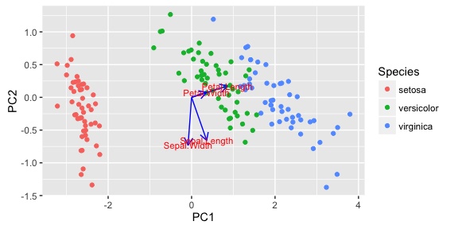

Figure 3: PCA with eigen-vectors and labels.

```r
autoplot(prcomp(df), data = iris, colour = "Species",
         loadings = TRUE, loadings.colour = 'blue',
         loadings.label = TRUE, loadings.label.size = 3)
```

### 3.2 Linear models

The *ggfortify* function is able able to interpret `lm()` fitted model objects and allows the user to select the subset of desired plots through the `which` parameter (just like the `plot.lm()` function). The `ncol` and `nrow` parameters also allow users to specify the number of subplot columns and rows, as seen in Figure 4 and the following code:

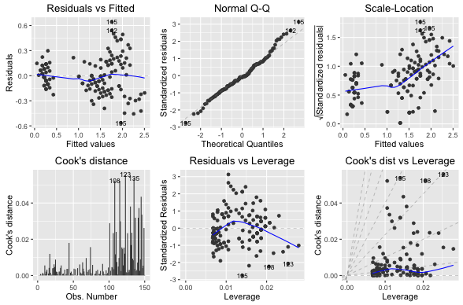

Figure 4: Linear model results.

```r
par(mfrow = c(1, 2))
m <- lm(Petal.Width ~ Petal.Length, data = iris)
autoplot(m, which = 1:6, ncol = 3, label.size = 3)
```

Many plot aesthetics can be changed by using the appropriate named parameters. For example, the `colour` parameter is for coloring data points, the `smooth.colour` parameter is for coloring smoothing lines and the `ad.colour` parameter is for coloring the auxiliary lines, as demonstrated in Figure 5 and the following code:

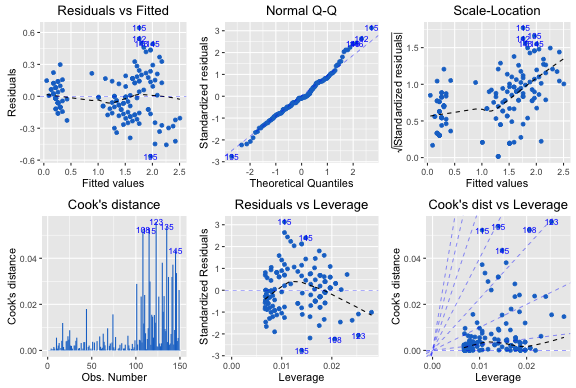

Figure 5: Linear model results with specified options.

```r
autoplot(m, which = 1:6, colour = "dodgerblue3",
         smooth.colour = "black", smooth.linetype = "dashed",
         ad.colour = "blue",
         label.size = 3, label.n = 5, label.colour = "blue",
         ncol = 3)
```

### 3.3 Clustering

The *ggfortify* package also supports various objects like `"clara"`, `"fanny"`, `"pam"`, `"kmeans"`, and `"lfda"`, from the [*cluster*](https://CRAN.R-project.org/package=cluster) (Maechler et al. 2015) and [*lfda*](https://CRAN.R-project.org/package=lfda) (Tang and Deane-Mayer 2016) packages. It automatically infers the object type and plots the results from those packages using *ggplot2* with a single function call. Users can specify `frame = TRUE` to easily draw the clustering boundaries as seen in Figure 6 and the following code:

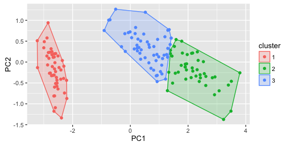

Figure 6: Clustering with boundaries.

```r
library(cluster)
autoplot(fanny(iris[-5], 3), frame = TRUE)
```

As illustrated in Figure 7 with `frame.type = "norm"`, by specifying `frame.type` users are able to draw boundaries of different shapes. The different frame types can be found in `frame.type` option in `ggplot2::stat_ellipse()`.

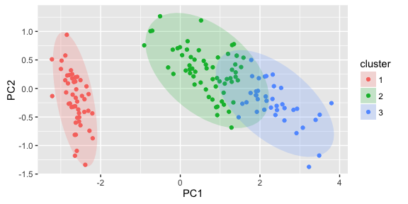

Figure 7: Clustering with boundaries in ellipse shape.

```r
autoplot(pam(iris[-5], 3), frame = TRUE, frame.type = "norm")
```

### 3.4 Time series

The *ggfortify* package makes it much easier to visualize time series objects using *ggplot2* and provides `autoplot()` and `fortify()` implementatons for ojects from many time series libraries such as [*zoo*](https://CRAN.R-project.org/package=zoo) (Zeileis and G. Grothendieck 2005), [*xts*](https://CRAN.R-project.org/package=xts) (Ryan and J. M. Ulrich 2014), and [*timeSeries*](https://CRAN.R-project.org/package=timeSeries) (Team et al. 2015).  
Here is an example of using *ggfortify* to plot the `AirPassengers` example time series data set from the *timeSeries* package, specifying color via `ts.colour`, geometric shape via `ts.geom` as seen in Figure 8, Figure 9, and Figure 10:

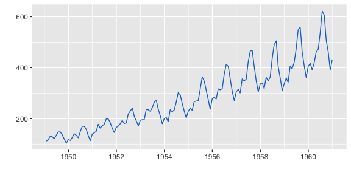

Figure 8: AirPassengers time series.

```r
library(timeSeries)
autoplot(as.timeSeries(AirPassengers), ts.colour = "dodgerblue3")
```

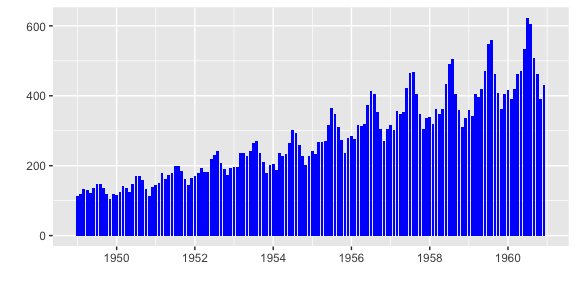

Figure 9: AirPassengers time series in bar shape.

```r
autoplot(AirPassengers, ts.geom = "bar", fill = "blue")
```

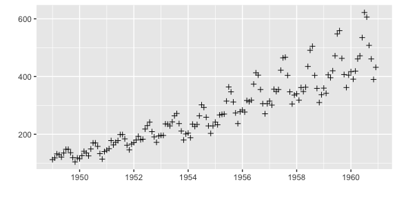

Figure 10: AirPassengers time series in point shape.

```r
autoplot(AirPassengers, ts.geom = "point", shape = 3)
```

### 3.5 Forecasting

Forecasting packages such as [*forecast*](https://CRAN.R-project.org/package=forecast) (Hyndman 2015), [*changepoint*](https://CRAN.R-project.org/package=changepoint) (Killick et al. 2016), [*strucchange*](https://CRAN.R-project.org/package=strucchange) (Zeileis et al. 2002), and [*dlm*](https://CRAN.R-project.org/package=dlm) (Petris 2010), are popular choices for statisticians and researchers. Predictions and statistical results from those packages can now be plotted automatically with *ggplot2* using the functions provided by *ggfortify*. Note that in these cases the order of loading packages matters. For example, since *forecast* has its own `autoplot()` function, if it is loaded before *ggfortify*, the `autoplot()` function in *forecast* will be used instead.  
The *ggfortify* function automatically plots the original and smoothed line from Kalman filter function in the *dlm* package as shown in Figure 11 .

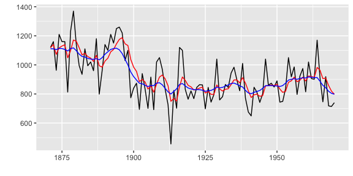

Figure 11: Smoothed time series by Kalman filter.

```r
library(dlm)
form <- function(theta){
  dlmModPoly(order = 1, dV = exp(theta[1]), dW = exp(theta[2]))
}

model <- form(dlmMLE(Nile, parm = c(1, 1), form)$par)
filtered <- dlmFilter(Nile, model)

autoplot(filtered)
```

The *ggfortify* package automatically plots the change points with optimal positioning for the `AirPassengers` data set found in the *changepoint* package using the `cpt.meanvar()` function, shown in Figure 12 .

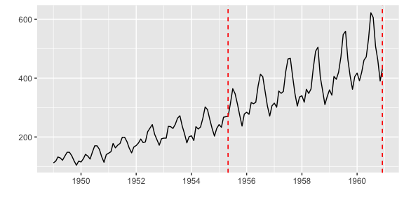

Figure 12: Change points with optimal positioning for AirPassengers.

```r
library(changepoint)
autoplot(cpt.meanvar(AirPassengers))
```

As well, *ggfortify* plots the optimal break points where possible structural changes happen in the regression models built by the `strucchange::breakpoints()`, shown in Figure 13.

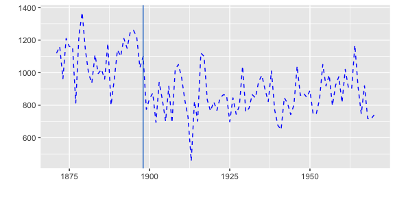

Figure 13: Optimal break points with possible structural changes.

```r
library(strucchange)
autoplot(breakpoints(Nile ~ 1), ts.colour = "blue", ts.linetype = "dashed",
         cpt.colour = "dodgerblue3", cpt.linetype = "solid")
```

## 4 Future development

We welcome suggestions and contributions from others. Providing default `autoplot()` and `fortify()` methods for additional R objects means researchers will spend less time focusing on *ggplot2* plotting details and more time on their work and research. We are have provided a Github repository https://github.com/sinhrks/ggfortify where users can test out development versions of the package and provide feature requests, feedback and bug reports. We encourage you to submit your issues and pull requests to help us make this package better for the R community.

## 5 Summary

The *ggfortify* package provides a very simple interface to streamline the process of plotting statistical results from many popular R packages. Users can spend more time and focus on their analyses instead of figuring out the details of how to visualize their results in *ggplot2*.

## 6 Acknowledgement

We sincerely thank all developers for their efforts behind the packages that *ggfortify* depend on, namely, [*dplyr*](https://CRAN.R-project.org/package=dplyr) (Wickham and R. Francois 2015), [*tidyr*](https://CRAN.R-project.org/package=tidyr) (Wickham 2016b), [*gridExtra*](https://CRAN.R-project.org/package=gridExtra) (Auguie 2016), and [*scales*](https://CRAN.R-project.org/package=scales) (Wickham 2016a).

### 6.1 CRAN packages used

lattice, ggplot2, ggfortify, cluster, lfda, zoo, xts, timeSeries, forecast, changepoint, strucchange, dlm, dplyr, tidyr, gridExtra, scales

### 6.2 CRAN Task Views implied by cited packages

Bayesian, ChemPhys, Cluster, Databases, Econometrics, Environmetrics, Finance, MissingData, ModelDeployment, NetworkAnalysis, Phylogenetics, Robust, Spatial, SpatioTemporal, TeachingStatistics, TimeSeries

B. Auguie. *gridExtra: Miscellaneous Functions for "Grid" Graphics, .* R package version 2.2.1, 2016. URL http://CRAN.R-project.org/package=gridExtra.

M. Horikoshi and Y. Tang. *ggfortify: Data Visualization Tools for Statistical Analysis Results, .* R package version 0.1.0, 2015. URL http://CRAN.R-project.org/package=ggfortify.

R. J. Hyndman. *forecast: Forecasting functions for time series and linear models.* 2015. URL http://github.com/robjhyndman/forecast. R package version 6.2.

R. Killick, K. Haynes and I. A. Eckley. *changepoint: An R package for changepoint analysis.* 2016. URL http://CRAN.R-project.org/package=changepoint. R package version 2.2.1.

M. Maechler, P. Rousseeuw, A. Struyf, M. Hubert and K. Hornik. *Cluster: Cluster analysis basics and extensions.* 2015. R package version 2.0.3 — For new features, see the ’Changelog’ file (in the package source).

G. Petris. An R package for dynamic linear models. *Journal of Statistical Software*, 36(12): 1–16, 2010. URL http://www.jstatsoft.org/v36/i12/.

J. A. Ryan and J. M. Ulrich. *xts: eXtensible Time Series, .* R package version 0.9-7, 2014. URL http://CRAN.R-project.org/package=xts.

D. Sarkar. *Lattice: Multivariate Data Visualization with R.* Springer New York, 2008. URL http://lmdvr.r-forge.r-project.org.

Y. Tang and Z. Deane-Mayer. *Lfda: Local fisher discriminant analysis.* 2016. URL https://github.com/terrytangyuan/lfda. R package version 1.1.1.

R. C. Team, D. Wuertz, T. Setz and Y. Chalabi. *timeSeries: Rmetrics - financial time series objects.* 2015. URL http://CRAN.R-project.org/package=timeSeries. R package version 3022.101.2.

H. Wickham and R. Francois. *dplyr: A Grammar of Data Manipulation, .* R package version 0.4.3, 2015. URL http://CRAN.R-project.org/package=dplyr.

H. Wickham. *ggplot2: Elegant graphics for data analysis.* Springer Science & Business Media, 2009.

H. Wickham. *scales: Scale Functions for Visualization, natexlaba.* R package version 0.4.0, 2016a. URL http://CRAN.R-project.org/package=scales.

H. Wickham. *tidyr: Easily Tidy Data with ‘spread()‘ and ‘gather()‘ Functions, natexlabb.* R package version 0.4.1, 2016b. URL http://CRAN.R-project.org/package=tidyr.

A. Zeileis, F. Leisch, K. Hornik and C. Kleiber. Strucchange: An R package for testing for structural change in linear regression models. *Journal of Statistical Software*, 7(2): 1–38, 2002. URL http://www.jstatsoft.org/v07/i02/.

A. Zeileis and G. Grothendieck. *zoo: S3 infrastructure for regular and irregular time series.* Journal of Statistical Software 14 (6):, 2005. URL http://www.jstatsoft.org/v14/i06/.

[^1]: http://adv-r.had.co.nz/S3.html
[^2]: https://github.com/sinhrks/ggfortify/issues